Technical test report Dr Holly Crompton 2026-04-13

# Introduction

This report presents the analysis of synthetic patient data generated using the Synthea platform. The data consists of five main datasets (patients, conditions, observations, encounters, and medications) linked by a common patient identifier, alongside three ontology dictionaries (SNOMED-CT, LOINC, and RxNorm) used to encode clinical concepts.

# Load libraries

```r
library(ggplot2)
library(spdep)
library(stringr)
library(knitr)
library(ggspatial)
library(sf)
library(dplyr)
library(tidyr)
library(here)
```

# Read in data files

```r
setwd("~/Documents/UCL_interview/")

conditions <- read.csv(gzfile('test_data/data/dest/conditions.csv.gz'), header = TRUE)
encounters <- read.csv(gzfile('test_data/data/dest/encounters.csv.gz'), header = TRUE)
medications <- read.csv(gzfile('test_data/data/dest/medications.csv.gz'), header = TRUE)
observations <- read.csv(gzfile('test_data/data/dest/observations.csv.gz'), header = TRUE)
patients <- read.csv(gzfile('test_data/data/dest/patients.csv.gz'), header = TRUE)

loinc <- read.csv('test_data/data/dest/dictionary_loinc.csv', header = TRUE)
rxnorm <- read.csv('test_data/data/dest/dictionary_rxnorm.csv', header = TRUE)
snomed <- read.csv('test_data/data/dest/dictionary_snomed.csv', header = TRUE)
```

# TASK 1

## Clean patients dataset

```r
summary(patients)
```

```
##       Id             BIRTHDATE          DEATHDATE             SSN
##  Length:1162        Length:1162        Length:1162        Length:1162
##  Class :character   Class :character   Class :character   Class :character
##  Mode  :character   Mode  :character   Mode  :character   Mode  :character
##
##
##
##
##    DRIVERS            PASSPORT            PREFIX             FIRST
##  Length:1162        Length:1162        Length:1162        Length:1162
##  Class :character   Class :character   Class :character   Class :character
##  Mode  :character   Mode  :character   Mode  :character   Mode  :character
##
##
##
##
##      LAST              SUFFIX             MAIDEN            MARITAL
##  Length:1162        Length:1162        Length:1162        Length:1162
##  Class :character   Class :character   Class :character   Class :character
##  Mode  :character   Mode  :character   Mode  :character   Mode  :character
##
##
##
##
##      RACE            ETHNICITY            GENDER           BIRTHPLACE
##  Length:1162        Length:1162        Length:1162        Length:1162
##  Class :character   Class :character   Class :character   Class :character
##  Mode  :character   Mode  :character   Mode  :character   Mode  :character
##
##
##
##
##    ADDRESS              CITY              STATE              COUNTY
##  Length:1162        Length:1162        Length:1162        Length:1162
##  Class :character   Class :character   Class :character   Class :character
##  Mode  :character   Mode  :character   Mode  :character   Mode  :character
##
##
##
##
##       ZIP            LAT             LON         HEALTHCARE_EXPENSES
##  Min.   :1001   Min.   :41.30   Min.   :-73.45   Min.   :     826
##  1st Qu.:1835   1st Qu.:42.10   1st Qu.:-71.52   1st Qu.:  444272
##  Median :2118   Median :42.31   Median :-71.14   Median : 1143230
##  Mean   :2001   Mean   :42.26   Mean   :-71.34   Mean   : 1256983
##  3rd Qu.:2190   3rd Qu.:42.45   3rd Qu.:-71.00   3rd Qu.: 1903693
##  Max.   :2861   Max.   :42.89   Max.   :-69.98   Max.   :23116549
##  NA's   :544
##  HEALTHCARE_COVERAGE
##  Min.   :       0
##  1st Qu.:    1286
##  Median :   17523
##  Mean   :  171904
##  3rd Qu.:  205508
##  Max.   :13562280
##
```

```r
nrow(patients) # 1162 patients in original dataset
```

```
## [1] 1162
```

```r
patients_clean <- patients %>%
  mutate(
    BIRTHDATE = as.Date(BIRTHDATE),
    DEATHDATE = as.Date(DEATHDATE)
  ) %>%
  # Exclude patients where BIRTHDATE is missing or in the future
  filter(
    !is.na(BIRTHDATE),
    BIRTHDATE <= Sys.Date()
  ) %>%
  # Exclude patients where DEATHDATE is in the future
  filter(
    is.na(DEATHDATE) | DEATHDATE <= Sys.Date()
  ) %>%
  # Exclude patients where DEATHDATE is before BIRTHDATE
  filter(
    is.na(DEATHDATE) | DEATHDATE > BIRTHDATE
  ) %>%
  # Exclude patients where patient ID appears more than once
  group_by(Id) %>%
  filter(n() == 1) %>%
  ungroup() %>%
  # Apply remaining transformations
  mutate(
    GENDER    = factor(GENDER, levels = c("M", "F")),
    RACE      = factor(RACE),
    ETHNICITY = factor(ETHNICITY),
    MARITAL   = factor(MARITAL,
                       levels = c("S", "M"),
                       labels = c("Single", "Married")),
    STATE     = factor(STATE),
    CITY      = factor(CITY),
    AGE       = as.numeric(difftime(Sys.Date(), BIRTHDATE, units = "weeks") / 52.25),
    age_group = cut(AGE,
                    breaks = c(0, 9, 19, 29,39, 49, 59, 69, 79, Inf),
                    labels = c("0-9", "10-19", "20-29", "30-39", "40-49", "50-59", "60-69", "70-79", "80+"),
                    right  = FALSE)
  ) %>%
  # Oldest living person is 122 years old, so filter out any ages above 122
filter(AGE <= 122) %>%
# Missing gender
filter(!is.na(GENDER), GENDER != "") %>%
# Invalid gender category (anything other than M or F)
filter(GENDER %in% c("M", "F"))


summary(patients_clean)
```

```
##       Id              BIRTHDATE            DEATHDATE
##  Length:1114        Min.   :1911-07-14   Min.   :1942-01-05
##  Class :character   1st Qu.:1958-11-20   1st Qu.:1991-03-04
##  Mode  :character   Median :1977-09-04   Median :2003-10-02
##                     Mean   :1976-08-07   Mean   :2000-10-02
##                     3rd Qu.:1999-04-19   3rd Qu.:2012-10-01
##                     Max.   :2021-09-24   Max.   :2021-09-29
##                                          NA's   :958
##      SSN              DRIVERS            PASSPORT            PREFIX
##  Length:1114        Length:1114        Length:1114        Length:1114
##  Class :character   Class :character   Class :character   Class :character
##  Mode  :character   Mode  :character   Mode  :character   Mode  :character
##
##
##
##
##     FIRST               LAST              SUFFIX             MAIDEN
##  Length:1114        Length:1114        Length:1114        Length:1114
##  Class :character   Class :character   Class :character   Class :character
##  Mode  :character   Mode  :character   Mode  :character   Mode  :character
##
##
##
##
##     MARITAL         RACE           ETHNICITY    GENDER   BIRTHPLACE
##  Single :147   white  :914   hispanic   : 101   M:530   Length:1114
##  Married:605   black  : 94   nonhispanic:1013   F:584   Class :character
##  NA's   :362   asian  : 72                              Mode  :character
##                XJniDSe: 15
##                other  : 11
##                ???-   :  6
##                (Other):  2
##    ADDRESS                   CITY               STATE         COUNTY
##  Length:1114        Boston     :111   Massachusetts:1114   Length:1114
##  Class :character   Springfield: 29                        Class :character
##  Mode  :character   Quincy     : 22                        Mode  :character
##                     Somerville : 22
##                     Worcester  : 22
##                     Lowell     : 21
##                     (Other)    :887
##       ZIP            LAT             LON         HEALTHCARE_EXPENSES
##  Min.   :1001   Min.   :41.30   Min.   :-73.45   Min.   :     826
##  1st Qu.:1835   1st Qu.:42.10   1st Qu.:-71.52   1st Qu.:  445945
##  Median :2118   Median :42.30   Median :-71.14   Median : 1153145
##  Mean   :2000   Mean   :42.25   Mean   :-71.34   Mean   : 1264503
##  3rd Qu.:2190   3rd Qu.:42.44   3rd Qu.:-71.00   3rd Qu.: 1926804
##  Max.   :2861   Max.   :42.89   Max.   :-69.98   Max.   :23116549
##  NA's   :520
##  HEALTHCARE_COVERAGE      AGE            age_group
##  Min.   :       0    Min.   :  4.544   80+    :161
##  1st Qu.:    1286    1st Qu.: 26.945   50-59  :149
##  Median :   17523    Median : 48.537   60-69  :142
##  Mean   :  173390    Mean   : 49.613   30-39  :139
##  3rd Qu.:  206189    3rd Qu.: 67.303   20-29  :133
##  Max.   :13562280    Max.   :114.592   10-19  :119
##                                        (Other):271
```

```r
nrow(patients_clean) # 1114 patients in cleaned dataset
```

```
## [1] 1114
```

The raw patient dataset contained **1162 patients**. The following quality control checks were applied to ensure data integrity:

- **Missing or future birthdates** — patients with no recorded birthdate or a birthdate after today were excluded
- **Future or implausible death dates** — patients with a death date after today were excluded as these are likely data entry errors
- **Death before birth** — patients where the recorded death date preceded the birth date were excluded as this is biologically impossible
- **Duplicate patient IDs** — all rows sharing a patient ID were removed to prevent double counting in analyses
- **Implausible age** — patients aged over 122 years were excluded based on the verified record for the oldest person ever recorded
- **Missing or invalid gender** — patients with no recorded gender or a gender value other than Male or Female were excluded

After applying these checks, **1114 patients** were retained for analysis, representing an exclusion of 48 patients (4.1%). All other datasets (conditions, encounters, medications, and observations) were subsequently filtered to retain only records belonging to these 1114 patients, ensuring consistency across all analyses.

```r
### Ensure only these patients appear in other datasets
conditions_clean <- conditions %>%
  filter(PATIENT %in% patients_clean$Id)
encounters_clean <- encounters %>%
  filter(PATIENT %in% patients_clean$Id)
medications_clean <- medications %>%
  filter(PATIENT %in% patients_clean$Id)
observations_clean <- observations %>%
  filter(PATIENT %in% patients_clean$Id)
```

## Clean conditions dataset

```r
conditions_clean <- conditions_clean %>%
  mutate(
    START = as.Date(START),
    STOP = as.Date(STOP)
  ) %>%
  # Exclude conditions where STOP date is before START date
  filter(
    is.na(STOP) | STOP > START
  )  %>%
# Exclude conditions where CODE is missing
    filter(
      !is.na(CODE),
      CODE != ""
    )
```

The conditions dataset was cleaned by removing records where the condition end date preceded the start date, and records with missing condition codes. Conditions were then linked to the cleaned patient dataset to enable cross-referencing of patient demographics with clinical diagnoses. Records where the condition start date preceded the patient’s birthdate or followed the patient’s death date were identified as implausible and examined. The SNOMED-CT dictionary was used to translate numeric condition codes into human-readable descriptions. Any condition codes not present in the SNOMED-CT dictionary were excluded from further analysis.

```r
### join with patient data and clean
conditions_joined <- conditions_clean %>%
  left_join(patients_clean, by = c("PATIENT" = "Id"))

# check if any cases where START date is before patient's birthdate or after deathdate or if STOP date is after deathdate
conditions_joined1 <- conditions_joined %>%
  filter(
    START >= BIRTHDATE,
    is.na(DEATHDATE) | START <= DEATHDATE,
    is.na(DEATHDATE) | is.na(STOP) | STOP <= DEATHDATE
  ) # conditions_joined1 had no fewer rows than conditions_joined, so none meet these criteria

nrow(conditions_joined)
```

```
## [1] 36715
```

```r
### join conditions_joined with snomed to get condition names
# Check for duplicate codes in snomed dictionary
sub <- snomed %>%
  group_by(CODE) %>%
  filter(n() > 1)

# remove duplicates
snomed <- snomed %>%
  distinct(CODE, .keep_all = TRUE)

# show any codes in conditions_joined that are not in snomed
setdiff(conditions_joined$CODE, snomed$CODE)
```

```
## [1] 283371005010  88828382999
```

```r
# remove any conditions with codes that are not in snomed
conditions_joined <- conditions_joined %>%
  filter(CODE %in% snomed$CODE)

conditions_joined <- conditions_joined %>%
  left_join(snomed, by = c("CODE"))
```

## Clean encounters dataset

```r
  encounters_clean <- encounters_clean %>%
  mutate(
    START = as.Date(START),
    STOP = as.Date(STOP)
  ) %>%
  # Exclude encounters where STOP date is before START date
  filter(
    is.na(STOP) | STOP >= START
  )  %>%
# CODE and REASONCODE should be character strings so convert to character
  mutate(
    CODE = as.character(CODE),
    REASONCODE = as.character(REASONCODE)
  ) ## no encounters were dropped by these filters

# check encounters_clean for any duplicate encounter IDs
duplicate_encounters <- encounters_clean %>%
  group_by(Id) %>%
  filter(n() > 1) # no duplicate encounter IDs found
```

The encounters dataset was cleaned by removing records where the encounter end date preceded the start date, and ensuring encounter and reason codes were stored as character strings. No duplicate encounter IDs were identified. Following linkage with patient data, **159 encounter records** were identified where the encounter date fell outside the patient’s valid date range (before birth or after death) and were excluded from further analysis.

```r
### join with patient data
encounters_joined <- encounters_clean %>%
  left_join(patients_clean, by = c("PATIENT" = "Id"))

# check if any cases where START date is before patient's birthdate or after deathdate or if STOP date is after deathdate

encounters_joined1 <- encounters_joined %>%
  filter(
    START >= BIRTHDATE,
    is.na(DEATHDATE) | START <= DEATHDATE,
    is.na(DEATHDATE) | is.na(STOP) | STOP <= DEATHDATE
  ) # encounters_joined1 had 159 fewer rows than encounters_joined

# View the 159 cases that were dropped by this filter
sub_encounters <- encounters_joined %>%
  filter(
    START < BIRTHDATE | (!is.na(DEATHDATE) & START > DEATHDATE) | (!is.na(DEATHDATE) & !is.na(STOP) & STOP > DEATHDATE)
  ) %>%
  select(PATIENT, START, STOP, BIRTHDATE, DEATHDATE)


## Therefore use encounters_joined1 for further analysis
```

## Clean medications dataset

```r
summary(medications_clean)
```

```
##     START               STOP             PATIENT             PAYER
##  Length:54848       Length:54848       Length:54848       Length:54848
##  Class :character   Class :character   Class :character   Class :character
##  Mode  :character   Mode  :character   Mode  :character   Mode  :character
##
##
##
##
##   ENCOUNTER             CODE             BASE_COST       PAYER_COVERAGE
##  Length:54848       Length:54848       Min.   :   0.01   Min.   :   0.00
##  Class :character   Class :character   1st Qu.:   0.02   1st Qu.:   0.00
##  Mode  :character   Mode  :character   Median :  18.23   Median :   0.00
##                                        Mean   : 189.04   Mean   :  32.57
##                                        3rd Qu.: 151.50   3rd Qu.:   0.00
##                                        Max.   :7011.48   Max.   :6546.40
##
##    DISPENSES          TOTALCOST           REASONCODE
##  Min.   :   -8.00   Min.   :1.000e-02   Min.   :5.602e+06
##  1st Qu.:    1.00   1st Qu.:4.760e+00   1st Qu.:5.582e+07
##  Median :   12.00   Median :3.548e+01   Median :5.962e+07
##  Mean   :   87.58   Mean   :1.305e+03   Mean   :2.011e+10
##  3rd Qu.:   28.00   3rd Qu.:4.758e+02   3rd Qu.:5.962e+07
##  Max.   :45000.00   Max.   :2.197e+06   Max.   :1.323e+14
##                                         NA's   :15195
```

```r
nrow(medications_clean) # 54848 medications in original dataset
```

```
## [1] 54848
```

```r
medications_clean <- medications_clean %>%
  mutate(
    START = as.Date(START),
    STOP = as.Date(STOP)
  ) %>%
  # Exclude medications where STOP date is before START date
  filter(
    is.na(STOP) | STOP > START
  )  %>%
  # DISPENSES cannot be negative
    filter(
      is.na(DISPENSES) | DISPENSES >= 0
    ) %>%
# exclude dispenses above 99th percentile to exclude implausibly high values
    filter(
      is.na(DISPENSES) | DISPENSES <= quantile(DISPENSES, 0.99, na.rm = TRUE)
    ) %>%
    # Exclude medications where CODE is missing
    filter(
      !is.na(CODE),
      CODE != ""
    ) %>%
# Reason code should be character string so convert to character
  mutate(
    REASONCODE = as.character(REASONCODE)
  ) # 50544 medications in cleaned dataset
```

The medications dataset was cleaned by removing records where the medication end date preceded the start date, records with negative dispense counts, and records where the dispense count exceeded the 99th percentile (used as a threshold for implausibly high values). Records with missing medication codes were also excluded. Following linkage with patient data, **10 medication records** were identified where the medication date fell outside the patient’s valid date range and were excluded. RxNorm codes were used to translate medication codes into human-readable drug names.

```r
### join with patient data and clean
medications_joined <- medications_clean %>%
  left_join(patients_clean, by = c("PATIENT" = "Id"))

# check if any cases where START date is before patient's birthdate or after deathdate or if STOP date is after deathdate
medications_joined1 <- medications_joined %>%
  filter(
    START >= BIRTHDATE,
    is.na(DEATHDATE) | START <= DEATHDATE,
    is.na(DEATHDATE) | is.na(STOP) | STOP <= DEATHDATE
  ) # medications_joined1 had 10 fewer rows than medications_joined

# view the 10 cases that were dropped by this filter
sub_medications <- medications_joined %>%
  filter(
    START < BIRTHDATE | (!is.na(DEATHDATE) & START > DEATHDATE) | (!is.na(DEATHDATE) & !is.na(STOP) & STOP > DEATHDATE)
  ) %>%
  select(PATIENT, START, STOP, BIRTHDATE, DEATHDATE)

## Therefore use medications_joined1 for further analysis
```

```r
### Join with rxnorm to get medication names
# Check for duplicate codes in rxnorm dictionary
rxnorm$CODE <- as.character(rxnorm$CODE)
sub <- rxnorm %>%
  group_by(CODE) %>%
  filter(n() > 1)

# remove duplicates
rxnorm <- rxnorm %>%
  distinct(CODE, .keep_all = TRUE)

summary(medications_joined1$CODE)
```

```
##    Length     Class      Mode
##     50534 character character
```

```r
# remove the .0 from the end of codes in medications_joined1
medications_joined1 <- medications_joined1 %>%
  mutate(
    CODE = gsub("\\.0$", "", CODE)
  )

# show any codes in medications_joined1 that are not in rxnorm
setdiff(medications_joined1$CODE, rxnorm$CODE)
```

```
## [1] "2833710--05010" "-7"
```

```r
# remove any medications with codes that are not in rxnorm
medications_joined1 <- medications_joined1 %>%
  filter(CODE %in% rxnorm$CODE)

medications_joined1 <- medications_joined1 %>%
  left_join(rxnorm, by = c("CODE"))
```

## Clean observations dataset and join with patient data

```r
summary(observations_clean)
```

```
##      DATE             PATIENT           ENCOUNTER           CATEGORY
##  Length:512426      Length:512426      Length:512426      Length:512426
##  Class :character   Class :character   Class :character   Class :character
##  Mode  :character   Mode  :character   Mode  :character   Mode  :character
##      CODE              VALUE              UNITS               TYPE
##  Length:512426      Length:512426      Length:512426      Length:512426
##  Class :character   Class :character   Class :character   Class :character
##  Mode  :character   Mode  :character   Mode  :character   Mode  :character
```

```r
nrow(observations_clean) # 512426 observations in original dataset
```

```
## [1] 512426
```

```r
observations_joined <- observations_clean %>%
  mutate(
    DATE = as.Date(DATE)
  )  %>%
  # join with patient data
    left_join(patients_clean, by = c("PATIENT" = "Id"))

# check if any cases where DATE is before patient's birthdate or after deathdate
observations_joined1 <- observations_joined %>%
  filter(
    DATE >= BIRTHDATE,
    is.na(DEATHDATE) | DATE <= DEATHDATE
  ) # observations_joined1 had 289 fewer rows than observations_joined

nrow(observations_joined1)
```

```
## [1] 512137
```

```r
## Therefore use observations_joined1 for further analysis
```

The observations dataset was linked to the cleaned patient dataset and filtered to remove records where the observation date preceded the patient’s birthdate or followed the patient’s death date. **289 observation records** were excluded on this basis. LOINC codes were used to translate observation codes into human-readable measurement names. Any observation codes not present in the LOINC dictionary were excluded from further analysis.

```r
### Join with loinc to get observation names
summary(loinc)
```

```
##      CODE           DESCRIPTION
##  Length:256         Length:256
##  Class :character   Class :character
##  Mode  :character   Mode  :character
```

```r
# Check for duplicate codes in loinc dictionary
sub <- loinc %>%
  group_by(CODE) %>%
  filter(n() > 1)

# remove duplicates
loinc <- loinc %>%
  distinct(CODE, .keep_all = TRUE)

# show any codes in observations_joined1 that are not in loinc
setdiff(observations_joined1$CODE, loinc$CODE)
```

```
## [1] "-7"             ""               "2833710--05010"
```

```r
# remove any observations with codes that are not in loinc
observations_joined1 <- observations_joined1 %>%
  filter(CODE %in% loinc$CODE)

observations_joined1 <- observations_joined1 %>%
  left_join(loinc, by = c("CODE"))
```

# TASK 2

## Patient demographics

This section provides a comprehensive description of the patient cohort, including demographic characteristics, geographic distribution, and the most frequently observed clinical concepts across conditions, medications, observations, and encounters. Spatial mapping is incorporated to explore geographic variation in patient distribution and healthcare utilisation across Massachusetts counties.

```r
nrow(patients_clean) # 1114 unique patients
```

```
## [1] 1114
```

```r
table(patients_clean$age_group)
```

```
##
##   0-9 10-19 20-29 30-39 40-49 50-59 60-69 70-79   80+
##    51   119   133   139   119   149   142   101   161
```

```r
table(patients_clean$GENDER)
```

```
##
##   M   F
## 530 584
```

```r
patients_clean$RACE <- factor(patients_clean$RACE, levels = c("asian", "black", "hawaiian", "native", "other", "white"))
table(patients_clean$RACE)
```

```
##
##    asian    black hawaiian   native    other    white
##       72       94        0        2       11      914
```

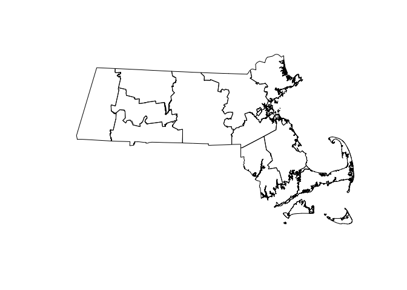

```r
## Geographic distribution of patients
# load shapefile of Massachusetts
counties <- st_read("counties/COUNTIES_POLY.shp")
plot(counties$geometry)
```

```r
head(counties)
```

```
## Simple feature collection with 6 features and 6 fields
## Geometry type: POLYGON
## Dimension:     XY
## Bounding box:  xmin: 219990.8 ymin: 907454.5 xmax: 267784.9 ymax: 959747.4
## Projected CRS: NAD83 / Massachusetts Mainland
##   FIPS_ID COUNTY AREA_ACRES OBJECTID   SHAPE_AREA   SHAPE_LEN
## 1   25009  ESSEX   316205.8        1 1.279634e+09 480777.4015
## 2   25009  ESSEX      119.1        2 4.818999e+05   3058.4963
## 3   25009  ESSEX       31.5        3 1.273319e+05   1437.2995
## 4   25009  ESSEX        1.3        4 5.383679e+03    318.2957
## 5   25009  ESSEX        7.1        5 2.857241e+04    884.5683
## 6   25009  ESSEX        6.3        6 2.564238e+04    696.0526
##                         geometry
## 1 POLYGON ((242115.9 912141.4...
## 2 POLYGON ((254695.8 950209.8...
## 3 POLYGON ((255037.7 950436, ...
## 4 POLYGON ((255527.3 949923.9...
## 5 POLYGON ((256263.3 946235.4...
## 6 POLYGON ((256167.4 945531, ...
```

```r
# patients_clean has LON and LAT in WGS84 and counties is in NAD83, so transform counties to WGS84
counties <- st_transform(counties, crs = 4326)

# join patients_clean based on spatial location with counties by LON and LAT only include Id, LON, LAT and COUNTY from patients_clean and COUNTY from counties
patients_clean_sf <- st_as_sf(patients_clean, coords = c("LON", "LAT"), crs = 4326)
counties <- counties %>%
  st_make_valid()
patients_joined_sf <- st_join(patients_clean_sf %>%
select(Id), counties, join = st_within, left = TRUE)
```

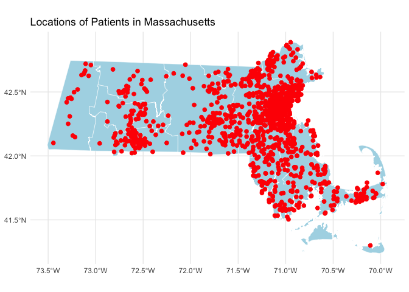

```r
### Plot patients on map of counties to check if any fall outside of Massachusetts
ggplot() +
  geom_sf(data = counties, fill = "lightblue", color = "white") +
  geom_sf(data = patients_joined_sf, color = "red", size = 2) +
  labs(title = "Locations of Patients in Massachusetts") +
  theme_minimal()
```

The map above shows the geographic distribution of patients across Massachusetts. A small number of patients fall outside county boundaries, likely due to coordinate rounding or patients residing close to county borders. These patients were assigned to the nearest county within Massachusetts provided they fell within 5km of the state border, ensuring all patients were assigned to a county for geographic analysis.

```r
### Assign patients to counties based on spatial location, but limit to 5km from border
# if any fall within 5km of the border of Massachusetts, assign them to the nearest county within Massachusetts
ma_border <- st_boundary(st_union(counties))

patients_joined_sf <- patients_joined_sf %>%
  mutate(
    distance_to_border = as.numeric(st_distance(geometry, ma_border)),
    nearest_county     = st_nearest_feature(geometry, counties)
  ) %>%
  mutate(
    COUNTY = ifelse(
      is.na(COUNTY) & distance_to_border <= 5000,
      counties$COUNTY[nearest_county],
      COUNTY
    )
  )

county_patient_counts <- patients_joined_sf %>%
  st_drop_geometry() %>%          # drop point geometry first
  group_by(COUNTY) %>%
  summarise(patient_count = n(), .groups = "drop")

# join counts to counties polygons
county_patient_counts_sf <- counties %>%
  left_join(county_patient_counts, by = "COUNTY")
```

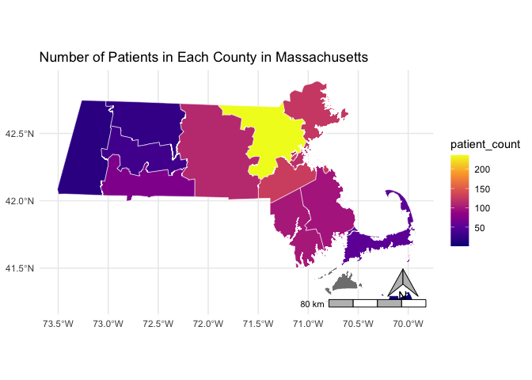

```r
### Plot
# create map of Massachusetts with counties colored by number of patients in each county
ggplot() +
  geom_sf(data = county_patient_counts_sf, aes(fill = patient_count), color = "white") +
  scale_fill_viridis_c(option = "plasma") +
  labs(title = "Number of Patients in Each County in Massachusetts") +
  theme_minimal() +
    annotation_north_arrow(location = "br", which_north = "true",
                                                              pad_x = unit(0.2, "in"), pad_y = unit(0.2, "in"), height = unit(0.4, "in"), width = unit(0.4, "in"),
                                                              style = ggspatial::north_arrow_orienteering(fill = c("grey", "grey"), line_col = "black")) +
    annotation_scale(location = "br", bar_cols = c("grey", "white"))
```

## Clinical Descriptives

The following sections describe the most frequently recorded clinical concepts across conditions, medications, and observations, alongside healthcare utilisation patterns by encounter type.

## Conditions

```r
## most common condition terms
conditions_joined %>%
  group_by(DESCRIPTION) %>%
  summarise(count = n(), code = first(CODE)) %>%
  arrange(desc(count)) %>%
  head(10) %>%
  kable(caption = "Top 10 Most Common Conditions")
```

Top 10 Most Common Conditions

| DESCRIPTION | count | code |
| --- | --- | --- |
| Full-time employment (finding) | 13426 | 160903007 |
| Stress (finding) | 4961 | 73595000 |
| Part-time employment (finding) | 2370 | 160904001 |
| Social isolation (finding) | 1201 | 422650009 |
| Viral sinusitis (disorder) | 1175 | 444814009 |
| Limited social contact (finding) | 1157 | 423315002 |
| Not in labor force (finding) | 1011 | 741062008 |
| Victim of intimate partner abuse (finding) | 773 | 706893006 |
| Acute viral pharyngitis (disorder) | 656 | 195662009 |
| Acute bronchitis (disorder) | 547 | 10509002 |

```r
## average number of conditions per patient
conditions_joined %>%
  group_by(PATIENT) %>%
  summarise(num_conditions = n()) %>%
  summarise(average_conditions = mean(num_conditions)) %>%
  kable(caption = "Average Number of Conditions per Patient")
```

Average Number of Conditions per Patient

| average_conditions |
| --- |
| 33.42714 |

```r
## most common co-morbidity pairs
patient_conditions <- conditions_joined %>%
  distinct(PATIENT, CODE, DESCRIPTION)

comorbidity_pairs <- patient_conditions %>%
  inner_join(patient_conditions, by = "PATIENT", relationship = "many-to-many") %>%
  # remove pairs where both conditions are the same
  filter(CODE.x < CODE.y) %>%
  count(CODE.x, DESCRIPTION.x, CODE.y, DESCRIPTION.y, sort = TRUE) %>%
  # calculate percentage of patients with each pair
  mutate(pct_patients = round(n / n_distinct(patient_conditions$PATIENT) * 100, 1))

head(comorbidity_pairs, 10)
```

```
##       CODE.x                  DESCRIPTION.x    CODE.y
## 1   73595000               Stress (finding) 160903007
## 2   73595000               Stress (finding) 160904001
## 3  160903007 Full-time employment (finding) 160904001
## 4   73595000               Stress (finding) 423315002
## 5   73595000               Stress (finding) 422650009
## 6   73595000               Stress (finding) 444814009
## 7  160903007 Full-time employment (finding) 423315002
## 8  160903007 Full-time employment (finding) 422650009
## 9  160903007 Full-time employment (finding) 444814009
## 10 160904001 Part-time employment (finding) 423315002
##                       DESCRIPTION.y   n pct_patients
## 1    Full-time employment (finding) 789         71.9
## 2    Part-time employment (finding) 661         60.2
## 3    Part-time employment (finding) 661         60.2
## 4  Limited social contact (finding) 630         57.4
## 5        Social isolation (finding) 619         56.4
## 6        Viral sinusitis (disorder) 582         53.0
## 7  Limited social contact (finding) 582         53.0
## 8        Social isolation (finding) 578         52.6
## 9        Viral sinusitis (disorder) 543         49.5
## 10 Limited social contact (finding) 500         45.5
```

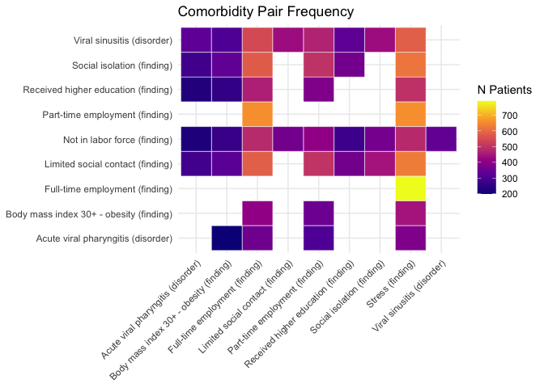

```r
# Create heatmap of comorbidity pairs for the top 10 most common conditions
top_conditions <- patient_conditions %>%
  count(DESCRIPTION) %>%
  slice_max(n, n = 10) %>%
  pull(DESCRIPTION)

# Filter pairs to only top conditions
comorbidity_pairs %>%
  filter(DESCRIPTION.x %in% top_conditions,
         DESCRIPTION.y %in% top_conditions) %>%
  ggplot(aes(x = DESCRIPTION.x, y = DESCRIPTION.y, fill = n)) +
  geom_tile(colour = "white") +
  scale_fill_viridis_c(option = "plasma") +
  labs(
    title = "Comorbidity Pair Frequency",
    x     = NULL,
    y     = NULL,
    fill  = "N Patients"
  ) +
  theme_minimal(base_size = 11) +
  theme(axis.text.x = element_text(angle = 45, hjust = 1))
```

## Medications

```r
## most common medication terms
medications_joined1 %>%
  group_by(DESCRIPTION) %>%
  summarise(count = n(), code = first(CODE)) %>%
  arrange(desc(count)) %>%
  head(10) %>%
  kable(caption = "Top 10 Most Common Medications")
```

Top 10 Most Common Medications

| DESCRIPTION | count | code |
| --- | --- | --- |
| lisinopril 10 MG Oral Tablet | 7768 | 314076 |
| Hydrochlorothiazide 25 MG Oral Tablet | 6889 | 310798 |
| amLODIPine 2.5 MG Oral Tablet | 5603 | 308136 |
| insulin human isophane 70 UNT/ML / Regular Insulin Human 30 UNT/ML Injectable Suspension [Humulin] | 3796 | 106892 |
| 24 HR Metformin hydrochloride 500 MG Extended Release Oral Tablet | 2912 | 860975 |
| Simvastatin 10 MG Oral Tablet | 2450 | 314231 |
| NDA020503 200 ACTUAT Albuterol 0.09 MG/ACTUAT Metered Dose Inhaler | 2168 | 2123111 |
| 120 ACTUAT Fluticasone propionate 0.044 MG/ACTUAT Metered Dose Inhaler | 2166 | 895994 |
| Nitroglycerin 0.4 MG/ACTUAT Mucosal Spray | 1505 | 705129 |
| Simvastatin 20 MG Oral Tablet | 1242 | 312961 |

## Observations

```r
## most common observation terms
observations_joined1 %>%
  group_by(DESCRIPTION) %>%
  summarise(count = n(), code = first(CODE)) %>%
  arrange(desc(count)) %>%
  head(10) %>%
  kable(caption = "Top 10 Most Common Observations")
```

Top 10 Most Common Observations

| DESCRIPTION | count | code |
| --- | --- | --- |
| Pain severity - 0-10 verbal numeric rating [Score] - Reported | 13972 | 72514-3 |
| Diastolic Blood Pressure | 13897 | 8462-4 |
| Systolic Blood Pressure | 13897 | 8480-6 |
| Body Weight | 12704 | 29463-7 |
| Heart rate | 12457 | 8867-4 |
| Respiratory rate | 12457 | 9279-1 |
| Body Height | 12146 | 8302-2 |
| Tobacco smoking status NHIS | 12113 | 72166-2 |
| Body Mass Index | 11064 | 39156-5 |
| What is your housing situation today? | 8607 | 71802-3 |

```r
  ## average number of observations per patient
observations_joined1 %>%
  group_by(PATIENT) %>%
  summarise(num_observations = n()) %>%
  summarise(average_observations = mean(num_observations)) %>%
    kable(caption = "Average Number of Observations per Patient")
```

Average Number of Observations per Patient

| average_observations |
| --- |
| 431.7639 |

## Encounters

```r
## Encounter class distribution
encounters_joined1 %>%
  group_by(ENCOUNTERCLASS) %>%
  summarise(count = n()) %>%
  arrange(desc(count)) %>%
  kable(caption = "Encounter Class Distribution")
```

Encounter Class Distribution

| ENCOUNTERCLASS | count |
| --- | --- |
| wellness | 23091 |
| ambulatory | 19463 |
| outpatient | 10359 |
| urgentcare | 2436 |
| emergency | 2086 |
| inpatient | 1660 |

```r
## Average number of encounters per patient
encounters_joined1 %>%
  group_by(PATIENT) %>%
  summarise(num_encounters = n()) %>%
  summarise(average_encounters = mean(num_encounters)) %>%
  kable(caption = "Average Number of Encounters per Patient")
```

Average Number of Encounters per Patient

| average_encounters |
| --- |
| 53.04758 |

## Healthcare utilisation by geographic location

```r
encounters_county <- encounters_joined1 %>%
  group_by(COUNTY, PATIENT) %>%
  summarise(num_encounters = n(), .groups = "drop") %>%
  group_by(COUNTY) %>%
  summarise(average_encounters = mean(num_encounters), .groups = "drop")

## make county names in encounters_county match those in counties
library(stringr)
encounters_county <- encounters_county %>%
  mutate(
    COUNTY = str_to_upper(COUNTY) %>%      # capitalise all
             str_remove(" COUNTY$") %>%    # remove trailing " County"
             str_trim()                    # remove any trailing whitespace
  )

setdiff(encounters_county$COUNTY, counties$COUNTY) # check if any county names in encounters_county do not match those in counties
```

```
## character(0)
```

```r
# join counts to counties polygons
encounters_county_sf <- counties %>%
  left_join(encounters_county, by = "COUNTY")
```

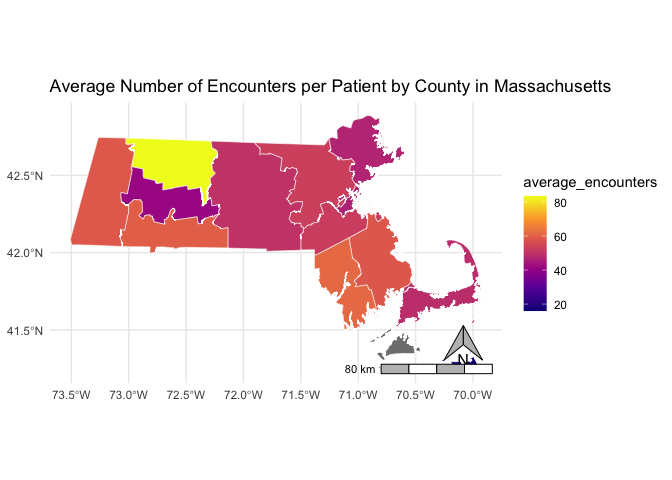

```r
### Plot
ggplot() +
  geom_sf(data = encounters_county_sf, aes(fill = average_encounters), color = "white") +
  scale_fill_viridis_c(option = "plasma") +
  labs(title = "Average Number of Encounters per Patient by County in Massachusetts") +
  theme_minimal() +
    annotation_north_arrow(location = "br", which_north = "true",
                                                              pad_x = unit(0.2, "in"), pad_y = unit(0.2, "in"), height = unit(0.4, "in"), width = unit(0.4, "in"),
                                                              style = ggspatial::north_arrow_orienteering(fill = c("grey", "grey"), line_col = "black")) +
    annotation_scale(location = "br", bar_cols = c("grey", "white"))
```

# TASK 3

## Create data for task 3

```r
## find code for hypertension in conditions_joined and filter to only patients with this code to find out how many patients have hypertension
conditions_joined %>%
    filter(str_detect(DESCRIPTION, regex("hypertension", ignore_case = TRUE))) %>%
  distinct(CODE, DESCRIPTION) %>%
  arrange(DESCRIPTION)
```

```
##       CODE  DESCRIPTION
## 1 59621000 Hypertension
```

```r
 ## create flag for patients diagnosed with hypertension (CODE = "59621000")
hypertension_flag <- conditions_joined %>%
  filter(CODE == "59621000") %>%
  distinct(PATIENT) %>%
  mutate(has_hypertension = TRUE)

cat("Total patients:            ", nrow(patients_clean), "\n")
```

```
## Total patients:             1114
```

```r
cat("Patients with hypertension:", nrow(hypertension_flag), "\n")
```

```
## Patients with hypertension: 281
```

```r
## find codes for Find BP and BMI in observations_joined1
observations_joined1 %>%
  filter(str_detect(DESCRIPTION, regex("blood pressure|body mass index|BMI", ignore_case = TRUE))) %>%
  distinct(CODE, DESCRIPTION) %>%
  arrange(DESCRIPTION)
```

```
##      CODE                                           DESCRIPTION
## 1 39156-5                                       Body Mass Index
## 2 59576-9 Body mass index (BMI) [Percentile] Per age and gender
## 3  8462-4                              Diastolic Blood Pressure
## 4  8478-0                                   Mean blood pressure
## 5  8480-6                               Systolic Blood Pressure
```

```r
## filter observations_joined1 to only include rows with these codes to find out how many patients have BP and BMI measurements
bp_bmi_data <- observations_joined1 %>%
  filter(CODE %in% c("8480-6",    # systolic BP
                     "8462-4",    # diastolic BP
                     "39156-5")) %>%  # BMI
mutate(
    VALUE = as.numeric(VALUE),
    measure = case_when(
      CODE == "8480-6"  ~ "Systolic BP",
      CODE == "8462-4"  ~ "Diastolic BP",
      CODE == "39156-5" ~ "BMI"
    )
  ) %>%
  # Remove implausible values
  filter(
    (measure == "Systolic BP"  & VALUE >= 50  & VALUE <= 300) |
    (measure == "Diastolic BP" & VALUE >= 20  & VALUE <= 200) |
    (measure == "BMI"          & VALUE >= 10  & VALUE <= 80)
  )

cat("BP/BMI observations:", nrow(bp_bmi_data), "\n")
```

```
## BP/BMI observations: 38857
```

```r
### Join bp_bmi_data with hypertension_flag to compare BP and BMI measurements between hypertensive and non-hypertensive patients
task3_data <- bp_bmi_data %>%
  left_join(hypertension_flag, by = "PATIENT") %>%
  mutate(has_hypertension = replace_na(has_hypertension, FALSE),
         group = if_else(has_hypertension, "Hypertensive", "Non-hypertensive"))

# Verify
task3_data %>%
  distinct(PATIENT, has_hypertension) %>%
  count(has_hypertension)
```

```
##   has_hypertension   n
## 1            FALSE 828
## 2             TRUE 281
```

Of the 1114 patients in the cleaned dataset, **281 (25.2%) had a recorded diagnosis of hypertension**. The distribution of systolic blood pressure, diastolic blood pressure, and BMI are compared between hypertensive and non-hypertensive patients in the tables and figures below.

```r
## Visualise differences in BP and BMI between hypertensive and non-hypertensive patients
## summary statistics
task3_summary <- task3_data %>%
  group_by(measure, group) %>%
  summarise(
    N      = n(),
    Mean   = round(mean(VALUE, na.rm = TRUE), 1),
    SD     = round(sd(VALUE, na.rm = TRUE), 1),
    Median = round(median(VALUE, na.rm = TRUE), 1),
    Q25    = round(quantile(VALUE, 0.25, na.rm = TRUE), 1),
    Q75    = round(quantile(VALUE, 0.75, na.rm = TRUE), 1),
    Min    = round(min(VALUE, na.rm = TRUE), 1),
    Max    = round(max(VALUE, na.rm = TRUE), 1),
    .groups = "drop"
  )

task3_summary %>%
  kable(caption = "Summary of BP and BMI by Hypertension Status")
```

Summary of BP and BMI by Hypertension Status

| measure | group | N | Mean | SD | Median | Q25 | Q75 | Min | Max |
| --- | --- | --- | --- | --- | --- | --- | --- | --- | --- |
| BMI | Hypertensive | 3767 | 27.9 | 3.6 | 28.0 | 27.3 | 29.7 | 14.1 | 44.3 |
| BMI | Non-hypertensive | 7297 | 25.2 | 5.4 | 27.7 | 20.6 | 29.2 | 13.5 | 43.2 |
| Diastolic BP | Hypertensive | 4438 | 86.4 | 15.5 | 83.0 | 77.0 | 98.0 | 23.0 | 121.0 |
| Diastolic BP | Non-hypertensive | 9459 | 79.2 | 9.3 | 80.0 | 76.0 | 83.0 | 23.0 | 120.0 |
| Systolic BP | Hypertensive | 4438 | 137.4 | 36.6 | 127.0 | 116.0 | 150.0 | 54.4 | 300.0 |
| Systolic BP | Non-hypertensive | 9458 | 123.5 | 26.1 | 120.0 | 113.0 | 128.0 | 55.5 | 300.0 |

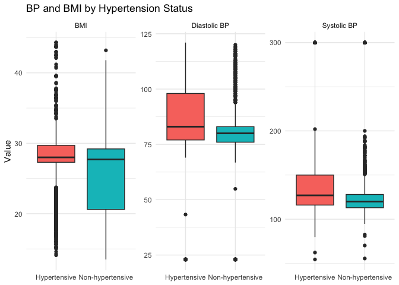

```r
## Boxplot of BP and BMI by hypertension status
ggplot(task3_data, aes(x = group, y = VALUE, fill = group)) +
  geom_boxplot() +
  facet_wrap(~ measure, scales = "free_y") +
  labs(title = "BP and BMI by Hypertension Status", x = NULL, y = "Value") +
  theme_minimal() +
  theme(legend.position = "none")
```

## Statistical testing to compare BP and BMI between hypertensive and non-hypertensive patients

```r
## WIlcoxon rank-sum test to compare BP and BMI between hypertensive and non-hypertensive patients
test_results <- task3_data %>%
  group_by(measure) %>%
  summarise(
    p_value = wilcox.test(VALUE ~ group)$p.value,
    .groups = "drop"
  ) %>%
  mutate(p_value = format.pval(p_value, digits = 3, eps = 0.001))

test_results %>%
  kable(caption = "Wilcoxon Rank-Sum Test Results Comparing BP and BMI Between Hypertensive and Non-Hypertensive Patients")
```

Wilcoxon Rank-Sum Test Results Comparing BP and BMI Between Hypertensive and Non-Hypertensive Patients

| measure | p_value |
| --- | --- |
| BMI | <0.001 |
| Diastolic BP | <0.001 |
| Systolic BP | <0.001 |

The Wilcoxon rank-sum test results indicate highly statistically significant differences in blood pressure and BMI between hypertensive and non-hypertensive patients. The geographic map below shows the mean systolic blood pressure in hypertensive patients by county, providing a spatial perspective on cardiovascular risk burden across Massachusetts.

## Map of geographic distribution of hypertensive patients

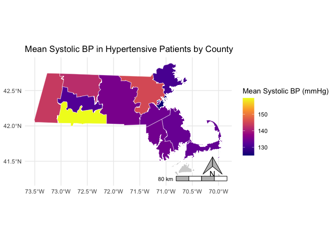

```r
bp_by_county <- task3_data %>%
  filter(measure == "Systolic BP") %>%
  mutate(
    COUNTY = str_to_upper(COUNTY) %>%
             str_remove(" COUNTY$") %>%
             str_trim()
  ) %>%
  group_by(COUNTY, group) %>%
  summarise(mean_sbp = round(mean(VALUE, na.rm = TRUE), 1), .groups = "drop")

# Map for hypertensive patients only
counties %>%
  left_join(bp_by_county %>% filter(group == "Hypertensive"), by = "COUNTY") %>%
  ggplot() +
  geom_sf(aes(fill = mean_sbp), color = "white") +
  scale_fill_viridis_c(option = "plasma", na.value = "lightgrey") +
  labs(title = "Mean Systolic BP in Hypertensive Patients by County",
       fill  = "Mean Systolic BP (mmHg)") +
  theme_minimal() +
  annotation_north_arrow(
    location = "br", which_north = "true",
    pad_x = unit(0.2, "in"), pad_y = unit(0.2, "in"),
    height = unit(0.4, "in"), width = unit(0.4, "in"),
    style = north_arrow_orienteering(
      fill = c("grey", "grey"), line_col = "black"
    )
  ) +
  annotation_scale(location = "br", bar_cols = c("grey", "white"))
```

# TASK 4

Two prevalence estimates are reported: crude prevalence, which reflects the raw proportion of patients with a hypertension diagnosis in this synthetic cohort, and age-standardised prevalence, which adjusts for the age structure of the population to allow comparison with published UK prevalence figures. Age standardisation was performed using the **2013 European Standard Population (ESP 2013)**, which is the reference population used by the Office for National Statistics (ONS) for age standardisation in the UK. Standardisation was performed overall and separately by sex.

## Crude prevalence of hypertension

```r
crude_prev <- nrow(hypertension_flag) / nrow(patients_clean) * 100
cat("Crude prevalence of hypertension:", round(crude_prev, 2), "%\n")
```

```
## Crude prevalence of hypertension: 25.22 %
```

## Prevalence of hypertension by age group

```r
hypertension_by_age <- patients_clean %>%
  left_join(hypertension_flag, by = c("Id" = "PATIENT")) %>%
  mutate(has_hypertension = replace_na(has_hypertension, FALSE)) %>%
  group_by(age_group) %>%
  summarise(
    N = n(),
    hypertension_cases = sum(has_hypertension),
    prevalence = round(hypertension_cases / N * 100, 1),
    .groups = "drop"
  )

hypertension_by_age %>%
  kable(caption = "Hypertension Prevalence by Age Group")
```

Hypertension Prevalence by Age Group

| age_group | N | hypertension_cases | prevalence |
| --- | --- | --- | --- |
| 0-9 | 51 | 0 | 0.0 |
| 10-19 | 119 | 0 | 0.0 |
| 20-29 | 133 | 32 | 24.1 |
| 30-39 | 139 | 37 | 26.6 |
| 40-49 | 119 | 33 | 27.7 |
| 50-59 | 149 | 48 | 32.2 |
| 60-69 | 142 | 51 | 35.9 |
| 70-79 | 101 | 29 | 28.7 |
| 80+ | 161 | 51 | 31.7 |

```r
esp_2013 <- tibble(
  age_group  = c("0-9", "10-19", "20-29", "30-39", "40-49",
                 "50-59", "60-69", "70-79", "80+"),
  esp_weight = c(
    # 0-9:   0-4 + 5-9
    5000 + 5500,
    # 10-19: 10-14 + 15-19
    5500 + 5500,
    # 20-29: 20-24 + 25-29
    6000 + 6000,
    # 30-39: 30-34 + 35-39
    6500 + 7000,
    # 40-49: 40-44 + 45-49
    7000 + 7000,
    # 50-59: 50-54 + 55-59
    7000 + 6500,
    # 60-69: 60-64 + 65-69
    6000 + 5500,
    # 70-79: 70-74 + 75-79
    5000 + 4000,
    # 80+:   80-84 + 85-89 + 90+
    2500 + 1500 + 1000
  )
) %>%
  mutate(esp_prop = esp_weight / sum(esp_weight))

esp_2013
```

```
## # A tibble: 9 × 3
##   age_group esp_weight esp_prop
##   <chr>          <dbl>    <dbl>
## 1 0-9            10500    0.105
## 2 10-19          11000    0.11
## 3 20-29          12000    0.12
## 4 30-39          13500    0.135
## 5 40-49          14000    0.14
## 6 50-59          13500    0.135
## 7 60-69          11500    0.115
## 8 70-79           9000    0.09
## 9 80+             5000    0.05
```

```r
standardised_prev <- hypertension_by_age %>%
  mutate(prevalence_prop = prevalence / 100) %>%
  left_join(esp_2013, by = "age_group") %>%
  mutate(weighted_prev = prevalence_prop * esp_prop) %>%
  summarise(
    std_prev     = sum(weighted_prev, na.rm = TRUE),
    std_prev_pct = round(std_prev * 100, 2)
  )

cat("Age-standardised prevalence:", standardised_prev$std_prev_pct, "%\n")
```

```
## Age-standardised prevalence: 23 %
```

## Separately by gender

```r
hypertension_by_age_sex <- patients_clean %>%
  mutate(has_hypertension = Id %in% hypertension_flag$PATIENT) %>%
  group_by(age_group, GENDER) %>%
  summarise(
    N                  = n(),
    hypertension_cases = sum(has_hypertension),
    prevalence_prop    = hypertension_cases / N,
    .groups            = "drop"
  )

standardised_by_sex <- hypertension_by_age_sex %>%
  left_join(esp_2013, by = "age_group") %>%
  mutate(weighted_prev = prevalence_prop * esp_prop) %>%
  group_by(GENDER) %>%
  summarise(
    std_prev_pct = round(sum(weighted_prev, na.rm = TRUE) * 100, 2),
    .groups      = "drop"
  ) %>%
  mutate(GENDER = if_else(GENDER == "F", "Female", "Male"))

standardised_by_sex %>%
  kable(caption = "Age-Standardised Hypertension Prevalence by Sex (ESP 2013)",
        col.names = c("Sex", "Standardised Prevalence (%)"))
```

Age-Standardised Hypertension Prevalence by Sex (ESP 2013)

| Sex | Standardised Prevalence (%) |
| --- | --- |
| Male | 24.36 |
| Female | 21.92 |

## Task 4 Summary

```r
tibble(
  Estimate = c(
    "Crude prevalence (overall)",
    "Age-standardised prevalence — Overall (ESP 2013)",
    "Age-standardised prevalence — Female (ESP 2013)",
    "Age-standardised prevalence — Male (ESP 2013)"
  ),
  `Prevalence (%)` = c(
    round(crude_prev, 2),
    standardised_prev$std_prev_pct,
    standardised_by_sex$std_prev_pct[standardised_by_sex$GENDER == "Female"],
    standardised_by_sex$std_prev_pct[standardised_by_sex$GENDER == "Male"]
  )
) %>%
  kable(caption = "Summary of Hypertension Prevalence Estimates")
```

Summary of Hypertension Prevalence Estimates

| Estimate | Prevalence (%) |
| --- | --- |
| Crude prevalence (overall) | 25.22 |
| Age-standardised prevalence — Overall (ESP 2013) | 23.00 |
| Age-standardised prevalence — Female (ESP 2013) | 21.92 |
| Age-standardised prevalence — Male (ESP 2013) | 24.36 |